# MBSL-day1

CB

2024-09-09

# Supervised classification and the learning process

## Linear Discriminant Analysis

To illustrate the learning process, let’s first consider Linear Discriminant Analysis (LDA) and the Iris data set:

```r
library(MASS)
?lda
```

```r
data(iris)
?iris
```

```r
dim(iris)
```

```
## [1] 150   5
```

```r
X = iris[,-5]
Y = iris$Species
```

Let’s now learn a first lda classifier (without respecting the minimal setup):

```r
f.lda = lda(X,Y)
```

We can have a look at what is inside the learned model:

```r
f.lda
```

```
## Call:
## lda(X, Y)
##
## Prior probabilities of groups:
##     setosa versicolor  virginica
##  0.3333333  0.3333333  0.3333333
##
## Group means:
##            Sepal.Length Sepal.Width Petal.Length Petal.Width
## setosa            5.006       3.428        1.462       0.246
## versicolor        5.936       2.770        4.260       1.326
## virginica         6.588       2.974        5.552       2.026
##
## Coefficients of linear discriminants:
##                     LD1         LD2
## Sepal.Length  0.8293776 -0.02410215
## Sepal.Width   1.5344731 -2.16452123
## Petal.Length -2.2012117  0.93192121
## Petal.Width  -2.8104603 -2.83918785
##
## Proportion of trace:
##    LD1    LD2
## 0.9912 0.0088
```

Once we have the classifier, we can predict the class of a new observation $x^*$:

```r
x.star = c(6,2.8,5,1.6)
out = predict(f.lda,x.star)
out
```

```
## $class
## [1] virginica
## Levels: setosa versicolor virginica
##
## $posterior
##            setosa versicolor virginica
## [1,] 4.477868e-30   0.333329  0.666671
##
## $x
##            LD1       LD2
## [1,] -4.124898 0.5731057
```

Let’s use CV for evaluating the performance of LDA:

```r
V = 15
fold = rep(1:V,nrow(X)/V)
err.lda = err.qda = rep(NA,V)
for (v in 1:V){
  # Split the data
  X.learn = X[fold!=v,]
  Y.learn = Y[fold!=v]
  X.val = X[fold==v,]
  Y.val = Y[fold==v]

  # Learn the classifier
  f.lda = lda(X.learn,Y.learn)
  f.qda = qda(X.learn,Y.learn)

  # Predict and evaluate the perf
  out.lda = predict(f.lda,X.val)
  out.qda = predict(f.qda,X.val)
  err.lda[v] = sum(out.lda$class != Y.val) / length(Y.val)
  err.qda[v] = sum(out.qda$class != Y.val) / length(Y.val)
}

cat("Err LDA:",mean(err.lda),"+/-",sd(err.lda),"\n")
```

```
## Err LDA: 0.02 +/- 0.04140393
```

```r
cat("Err QDA:",mean(err.qda),"+/-",sd(err.qda),"\n")
```

```
## Err QDA: 0.03333333 +/- 0.06172134
```

## Comparison with a ML technique: k-NN

Let’s first use k-NN to classify a new data point $x^*$:

```r
library(class)
?knn
```

Conversly to LDA, there is no learning phase with knn and the call is just:

```r
x.star = c(6,2.8,5,1.6)
out.knn = knn(X,x.star,Y,k=3)
out.knn
```

```
## [1] virginica
## Levels: setosa versicolor virginica
```

> Exercise: adapt the above CV code for comparing the performance of LDA and 3-NN.

```r
V = 15
fold = rep(1:V,nrow(X)/V)
err.lda = err.knn = rep(NA,V)
for (v in 1:V){
  # Split the data
  X.learn = X[fold!=v,]
  Y.learn = Y[fold!=v]
  X.val = X[fold==v,]
  Y.val = Y[fold==v]

  # Learn the classifier
  f.lda = lda(X.learn,Y.learn)

  # Predict and evaluate the perf
  out.lda = predict(f.lda,X.val)
  out.knn = knn(X.learn,X.val,Y.learn,k=3)
  err.lda[v] = sum(out.lda$class != Y.val) / length(Y.val)
  err.knn[v] = sum(out.knn != Y.val) / length(Y.val)
}

cat("Err LDA:",mean(err.lda),"+/-",sd(err.lda),"\n")
```

```
## Err LDA: 0.02 +/- 0.04140393
```

```r
cat("Err 3-NN:",mean(err.knn),"+/-",sd(err.knn),"\n")
```

```
## Err 3-NN: 0.04 +/- 0.05070926
```

This procedure (simple CV) allows to compare correctly two methods without tuning parameters. If you would like to know the general performance of k-NN, you have to use a double-CV procedure.

Before that, let’s look at the effect of varying k on the classification error:

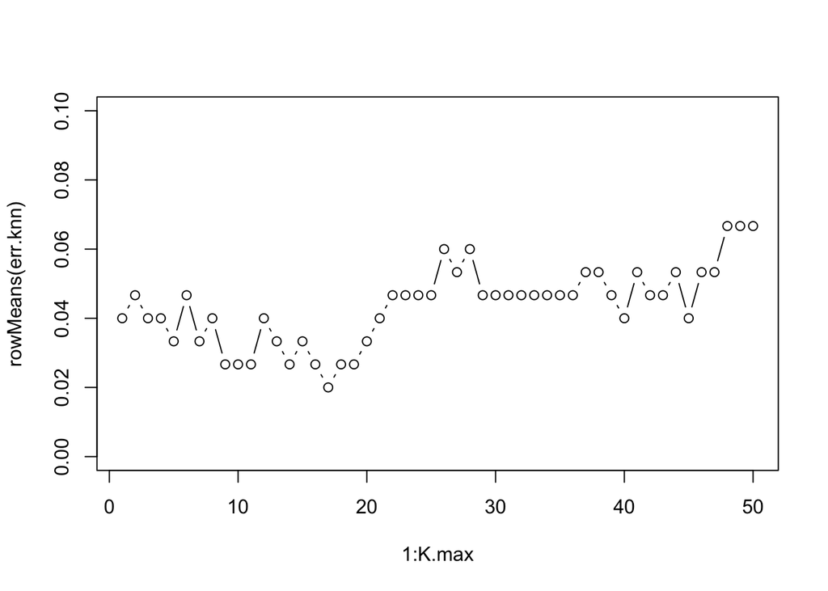

```r
V = 15
K.max = 50
fold = rep(1:V,nrow(X)/V)
err.knn = matrix(NA,K.max,V)

for (k in 1:K.max){
  for (v in 1:V){
    # Split the data
    X.learn = X[fold!=v,]
    Y.learn = Y[fold!=v]
    X.val = X[fold==v,]
    Y.val = Y[fold==v]

    out.knn = knn(X.learn,X.val,Y.learn,k)
    err.knn[k,v] = sum(out.knn != Y.val) / length(Y.val)
  }
}

plot(1:K.max,rowMeans(err.knn),type='b',ylim = c(0,0.1))
```

And thanks to this, we can write a short function that will find by (internal) CV the best value of k for a give data set:

```r
knn.bestk <- function(X,Y,V=15,K.max=30){
  fold = rep(1:V,nrow(X)/V)
  err.knn = matrix(NA,K.max,V)
  for (k in 1:K.max){
    for (v in 1:V){
      # Split the data
      X.learn = X[fold!=v,]
      Y.learn = Y[fold!=v]
      X.val = X[fold==v,]
      Y.val = Y[fold==v]

      out.knn = knn(X.learn,X.val,Y.learn,k)
      err.knn[k,v] = sum(out.knn != Y.val) / length(Y.val)
    }
  }
  return(which.min(rowMeans(err.knn)))
}

knn.bestk(X,Y)
```

```
## [1] 17
```

And now, we can re-use the CV procedure to compare LDA and k-NN (with the internal search of the best k by CV):

> Exercise: do it!

```r
V = 15
fold = rep(1:V,nrow(X)/V)
err.lda = err.knn = rep(NA,V)
k.star = rep(NA,V)
for (v in 1:V){
  # Split the data
  X.learn = X[fold!=v,]
  Y.learn = Y[fold!=v]
  X.val = X[fold==v,]
  Y.val = Y[fold==v]

  # Learn and predict for LDA
  f.lda = lda(X.learn,Y.learn)
  out.lda = predict(f.lda,X.val)

  # Find the best k for k-nn and predict
  k.star[v] = knn.bestk(X.learn,Y.learn)
  out.knn = knn(X.learn,X.val,Y.learn,k=k.star[v])

  # Evaluate the errors
  err.lda[v] = sum(out.lda$class != Y.val) / length(Y.val)
  err.knn[v] = sum(out.knn != Y.val) / length(Y.val)
}

cat("Err LDA:",mean(err.lda),"+/-",sd(err.lda),"\n")
```

```
## Err LDA: 0.02 +/- 0.04140393
```

```r
cat("Err k-NN:",mean(err.knn),"+/-",sd(err.knn),"\n")
```

```
## Err k-NN: 0.03333333 +/- 0.048795
```

```r
cat("Average k for k-NN:",median(k.star))
```

```
## Average k for k-NN: 11
```

## Logistic regression

A basic call to logistic regression in R is as follows:

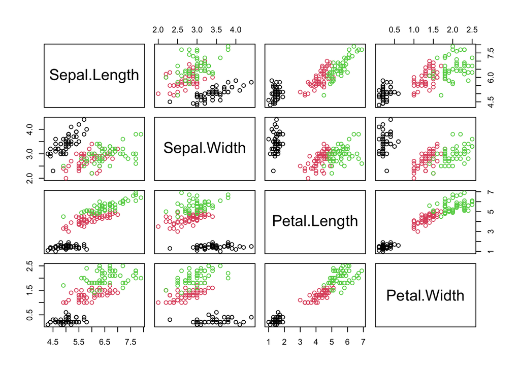

```r
pairs(X,col=Y)
```

To transform the Iris classification problem (with 3 classes) in a binary one, I propose to gather the classes 2 and 3.

```r
Y.bin = as.numeric(Y)
Y.bin[Y.bin==3] = 2
data = data.frame(X = X, Y = as.factor(Y))
f.lreg = glm(Y ~ ., data = data, family = "binomial")
f.lreg
```

```
##
## Call:  glm(formula = Y ~ ., family = "binomial", data = data)
##
## Coefficients:
##    (Intercept)  X.Sepal.Length   X.Sepal.Width  X.Petal.Length   X.Petal.Width
##         16.946         -11.759          -7.842          20.088          21.608
##
## Degrees of Freedom: 149 Total (i.e. Null);  145 Residual
## Null Deviance:       191
## Residual Deviance: 3.294e-09     AIC: 10
```

And classifying $x^*$ can be done as follows:

```r
data[151,] = c(5,2.8,2,1.6,NA)
out.lreg = predict(f.lreg,data[151,1:4],type = "response")
out.lreg
```

```
##       151
## 0.9999823
```

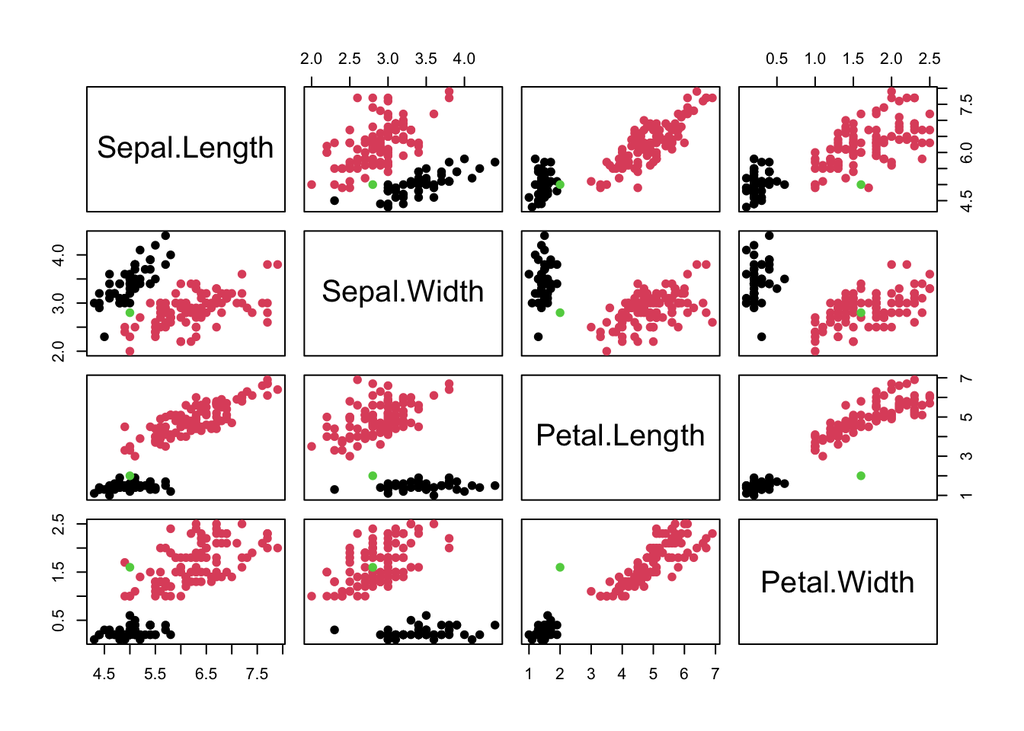

```r
pairs(rbind(X,c(5,2.8,2,1.6)),col=c(Y.bin,3),pch=19)
```

> Exercise: evaluate and compare the performance of LDA and logistic regression on this (binary) classification problem using CV

```r
Y.bin = as.numeric(Y)
Y.bin[Y.bin==2] = 1
Y.bin[Y.bin==3] = 2

# Using Y.bin instead of Y !!!
V = 15
fold = rep(1:V,nrow(X)/V)
err.lda = err.qda = err.knn = err.lreg = rep(NA,V)
k.star = rep(NA,V)
for (v in 1:V){
  # Split the data
  X.learn = X[fold!=v,]
  Y.learn = Y.bin[fold!=v]
  X.val = X[fold==v,]
  Y.val = Y.bin[fold==v]

  # Learn and predict for LDA
  f.lda = lda(X.learn,Y.learn)
  out.lda = predict(f.lda,X.val)

  # Learn and predict for QDA
  f.qda = qda(X.learn,Y.learn)
  out.qda = predict(f.qda,X.val)

  # Find the best k for k-nn and predict
  k.star[v] = knn.bestk(X.learn,Y.learn)
  out.knn = knn(X.learn,X.val,Y.learn,k=k.star[v])

  # for log. reg
  data = data.frame(X = X.learn, Y = as.factor(Y.learn))
  colnames(data) = c(colnames(X.learn),"Y")
  f.lreg = glm(Y ~ ., data = data, family = "binomial")
  out.lreg = (predict(f.lreg,X.val,type = "response") >= 0.5) + 1

  # Evaluate the errors
  err.lda[v] = sum(out.lda$class != Y.val) / length(Y.val)
  err.qda[v] = sum(out.qda$class != Y.val) / length(Y.val)
  err.knn[v] = sum(out.knn != Y.val) / length(Y.val)
  err.lreg[v] = sum(out.lreg != Y.val) / length(Y.val)
}
cat("Err LDA:",mean(err.lda),"+/-",sd(err.lda),"\n")
```

```
## Err LDA: 0.08 +/- 0.08618916
```

```r
cat("Err QDA:",mean(err.qda),"+/-",sd(err.qda),"\n")
```

```
## Err QDA: 0.03333333 +/- 0.06172134
```

```r
cat("Err lreg:",mean(err.lreg),"+/-",sd(err.lreg),"\n")
```

```
## Err lreg: 0.02 +/- 0.04140393
```

```r
cat("Err k-NN:",mean(err.knn),"+/-",sd(err.knn),"\n")
```

```
## Err k-NN: 0.04 +/- 0.05070926
```

```r
cat("Average k for k-NN:",median(k.star))
```

```
## Average k for k-NN: 11
```

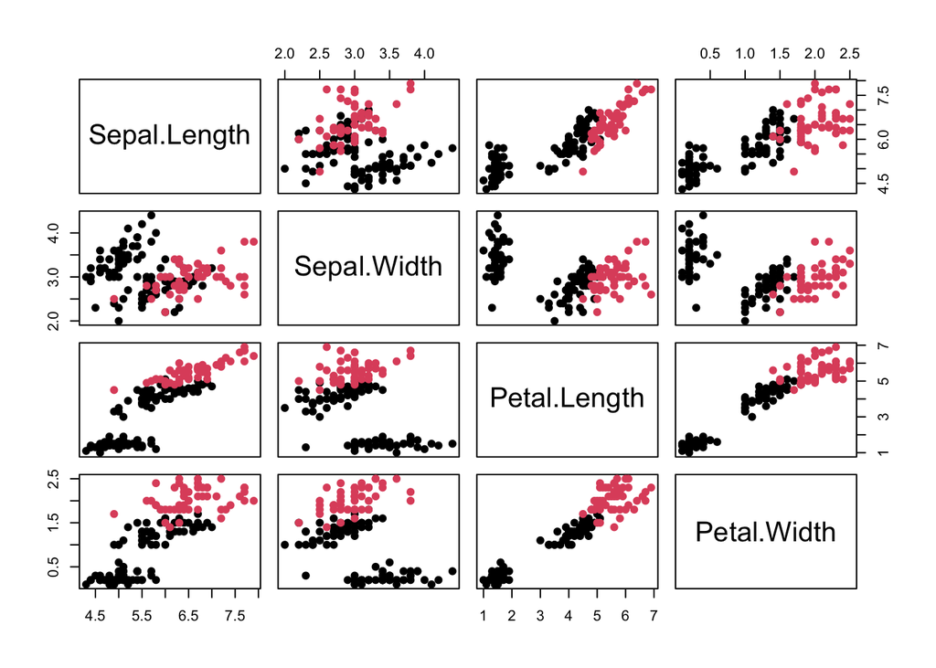

```r
pairs(X,col=Y.bin,pch=19)
```

Just for easing the interpretation of the classifiers, it is possible to plot the classification boundaries when we consider 2-D data (the two first variables for instance, for which the classification is difficult):

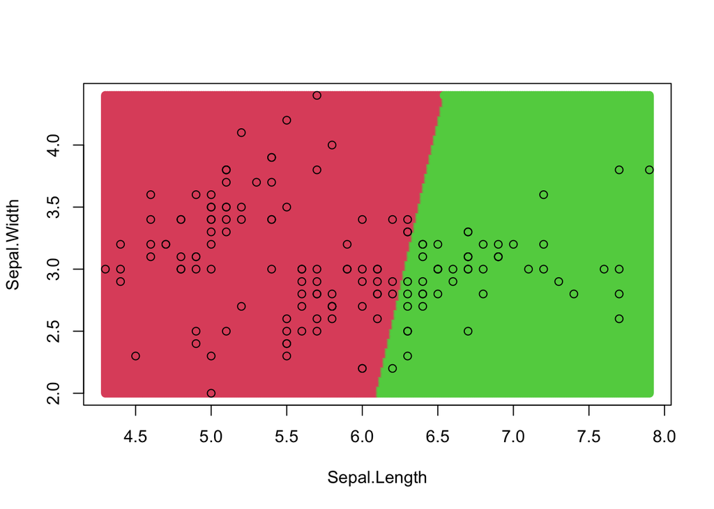

```r
XX = X[,1:2]
x <- seq(min(XX[,1]),max(XX[,1]),length.out = 250)
y <- seq(min(XX[,2]),max(XX[,2]), length.out = 250)
S = expand.grid(x,y)
colnames(S) = colnames(XX)

f.lda = lda(XX,Y.bin)
out.lda = predict(f.lda,S)

plot(XX,type='n')
points(S,col=as.numeric(out.lda$class)+1,pch=19)
points(XX,col=1)
```